# W4 Notes: Wilcoxon Tests

# Day 1

1 Sample t test (use a Signed-Rank Test) test statistic: x-bar Ho: mew = (a value)

2 Sample Paired t test (use a Signed-Rank Test) test statistic: d-bar Ho: d = 0

2 Sample Independent t test (use a Rank Sum Test) test statistic: (x-bar_1 - x-bar_2) Ho: (mew_1 - mew_2) = 0

- If you have ties then you’ll have to point that out in the analysis
- If you have zeroes you will have to do likewise

# Set up

```r
library(mosaic)
library(car)
```

# Trying Wilcoxon Tests

```r
wilcox.test(length ~ sex,
            data=KidsFeet)
```

```
##
##  Wilcoxon rank sum test with continuity correction
##
## data:  length by sex
## W = 252, p-value = 0.0836
## alternative hypothesis: true location shift is not equal to 0
```

Since the wilcoxon test had ties in the rankings, let’s try a t-test.

First test normality:

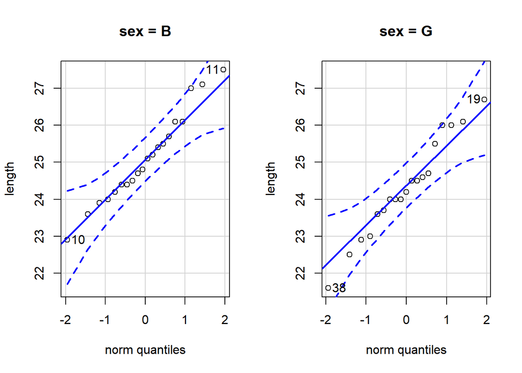

```r
qqPlot(length ~ sex,
       data = KidsFeet)
```

Looks great! Now for the t-test:

```r
t.test(length ~ sex,
       data = KidsFeet)
```

```
##
##  Welch Two Sample t-test
##
## data:  length by sex
## t = 1.9174, df = 36.275, p-value = 0.06308
## alternative hypothesis: true difference in means is not equal to 0
## 95 percent confidence interval:
##  -0.04502067  1.61291541
## sample estimates:
## mean in group B mean in group G
##        25.10500        24.32105
```

This works out great! Wilcoxon tests might not work well here because Wilcoxon is more used when you’re analyizing ranks (like first, second, and third place in class rankings).

If the t-test requirements are met, do that. If the distribution is not parametric, or if you’re dealing with ordinal data instead of quantitative data.

# Questions

What does “alternative hypothesis: true location shift is not equal to 0” mean?

- that you have repeat values in the list? This means that when ranking the values, there were ties between ranks.
- if there are a lot of ties, a Wilcoxon test won’t work.

What is “stochastically” mean?

- when the distribution is taller, or wider than a normal distribution?

# Day 2

library(mosaic) library(car) library(pander) library(DT) View(Friendly) ?Friendly

# SKills Quiz

## Set up

```r
#install.packages("cars")
```

```r
library(car)
library(mosaic)
```

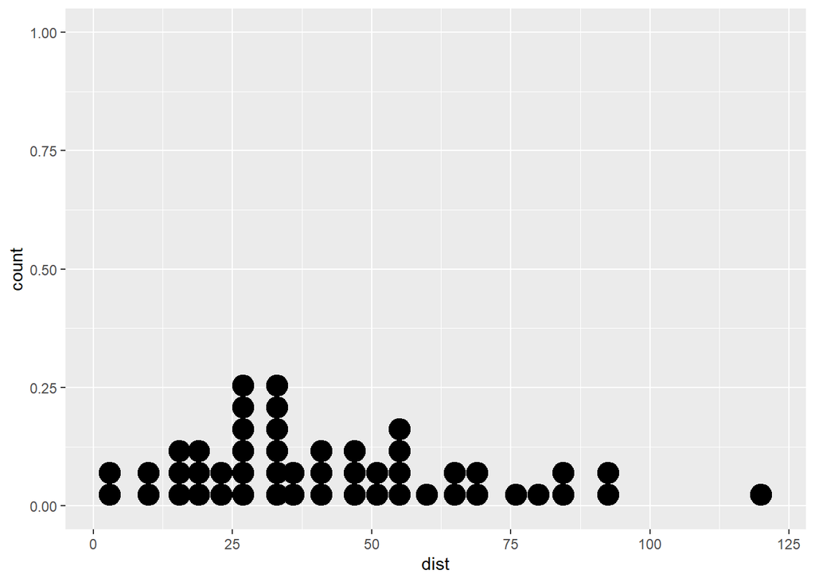

```r
ggplot(cars) +
   geom_dotplot(aes(x=dist))
```

```r
max(cars$dist)
```

```
## [1] 120
```

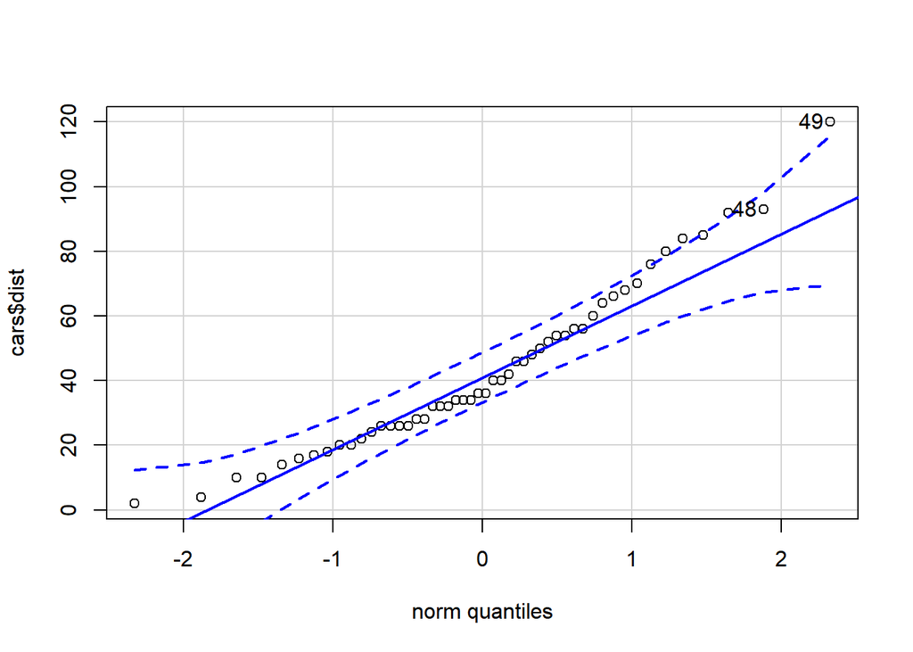

```
## [1] 49 48
```

```r
qqPlot(cars$dist)
```

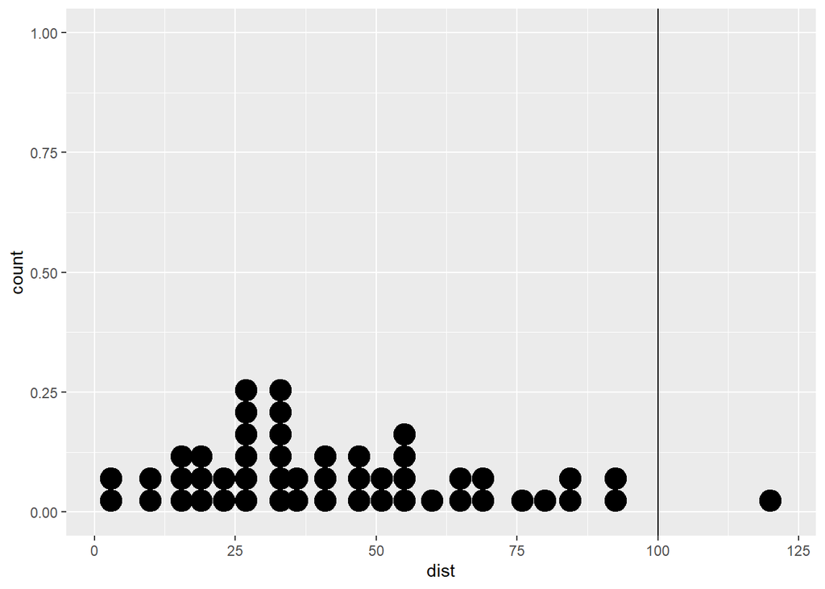

```r
ggplot(cars) +
   geom_dotplot(aes(x=dist)) +
   geom_vline(xintercept=100)
```

```r
wilcox.test(cars$dist, mu = 100, alternative = "two.sided")
```

```
##
##  Wilcoxon signed rank test with continuity correction
##
## data:  cars$dist
## V = 5.5, p-value = 1.081e-09
## alternative hypothesis: true location is not equal to 100
```

Recreate the dot plot used in the previous question by running the code:

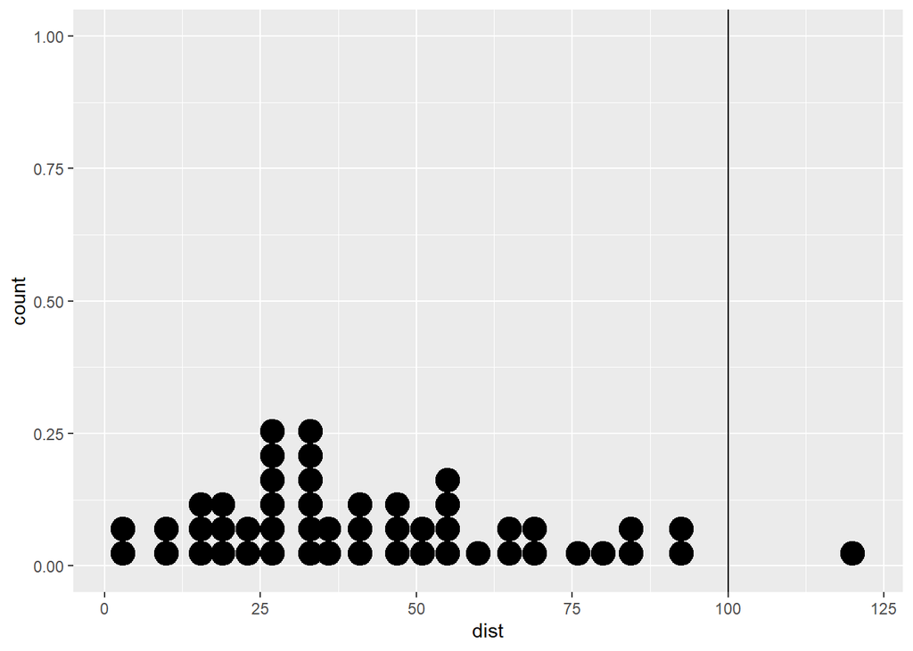

```r
ggplot(cars) +
  geom_dotplot(aes(x=dist)) +
  geom_vline(xintercept=100) #Adds the vertical line representing the null hypothesis
```

Before beginning Step 1 of the Wilcoxon Test, we need to calculate the “differences”. As stated in your textbook, "The differences are obtained by subtracting the hypothesized value for the median from all observations.

```r
differences <- (cars$dist - 100)
differences
```

```
##  [1] -98 -90 -96 -78 -84 -90 -82 -74 -66 -83 -72 -86 -80 -76 -72 -74 -66 -66 -54
## [20] -74 -64 -40 -20 -80 -74 -46 -68 -60 -68 -60 -50 -58 -44 -24 -16 -64 -54 -32
## [39] -68 -52 -48 -44 -36 -34 -46 -30  -8  -7  20 -15
```

As shown in your dot plot there is only one positive difference, this is the single dot to the right of the vertical line in your dotplot. All the other values are negative as they are to the left of the hypothesized value of 100.

What is the value of the single positive difference for this data?

```r
20
```

```
## [1] 20
```

What rank will this single positive difference be given? Hint the first eight negative differences (in order of magnitude) are -7, -8, -15, -16, -20, -24, -30, and -32?

(Remember: if there is a tie between two ranks, then the ranks of the two values are averaged together.)

Note that this answer is exactly the same as the value of the test statistic that you obtained in your test in R from the previous question! To see this, rerun the wilcox.test() from the previous question with the code:

```r
wilcox.test(cars$dist, mu = 100, alternative = "two.sided")
```

```
##
##  Wilcoxon signed rank test with continuity correction
##
## data:  cars$dist
## V = 5.5, p-value = 1.081e-09
## alternative hypothesis: true location is not equal to 100
```

There are two things needed to calculate the p-value of a hypthesis test. Which of these two things have we calculated so far?

A test statistic.

So, to calculate the p-value, we must now come up with all of the possible values that the test statistic could have been, and the probability of each value occurring. This is known as the distribution of the test statistic.

First, note that it could have been possible that none of the values were greater than 100. In this case, the sum of the positive ranks would have been: 0

> sum(1:50)

```r
sum(1:50)
```

```
## [1] 1275
```

This means that the test statistic of the Wilcoxon Test could have been any whole number between 0 and 1275.

## Question 5

This final set of questions is to help you verify that you can use R to answer research questions that utilize the Wilcoxon Tests.

Consider the Duncan dataset in R. (Ensure library(mosaic) and library(car) is loaded.)

Filter the data set to just show “wc” and “prof” types of occupations. Then, create Q-Q Plots of prestige scores for (1) the professional and managerial occupations and (2) the white-collar occupations.

```r
library(car)
#View(Duncan)
```

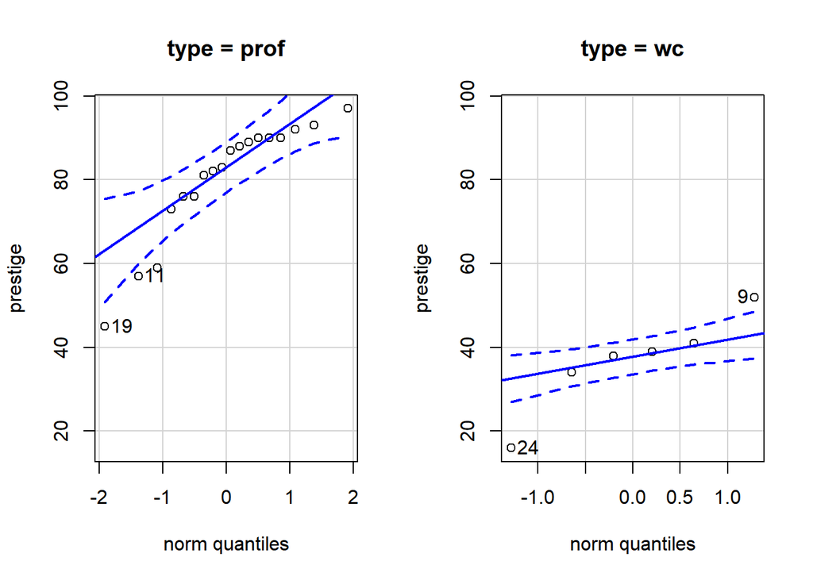

```r
Duncan2 <- Duncan %>%
  filter(type != "bc") %>%
  droplevels()

qqPlot(prestige ~ type,
       data = Duncan2
       )
```

Notice that the small sample size and potentially non-normal looking data suggests that a Wilcoxon Test is more appropriate than a t Test. Use an appropriate Wilcoxon Test that would answer the following question using the Duncan dataset in R.

Are prestige scores typically higher for professional and managerial occupations than for white-collar occupations?

```r
wilcox.test(
  Duncan$prestige[
    Duncan$type == "prof"],
  Duncan$prestige[
    Duncan$type == "wc"],
  mu = 0,
  alternative = "greater",
  conf.level = 0.95)
```

```
##
##  Wilcoxon rank sum test with continuity correction
##
## data:  Duncan$prestige[Duncan$type == "prof"] and Duncan$prestige[Duncan$type == "wc"]
## W = 107, p-value = 0.0002293
## alternative hypothesis: true location shift is greater than 0
```

My Answer: reject the null.

### part 2

Use the Salaries dataset in R. (Ensure the library(mosaic) is loaded.) Consider side-by-side box plots of salary according to gender for just the professors.

```r
library(mosaic)
```

```r
#(Salaries)
#?Salaries
```

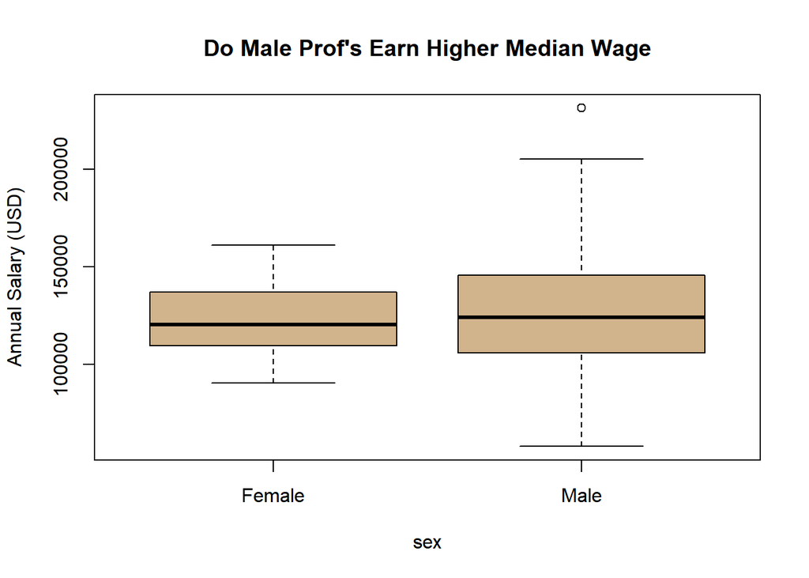

```r
Salariesprof <- Salaries %>%
  filter(rank == 'Prof')

boxplot(salary ~ sex,
        data = Salariesprof,
        ylab = "Annual Salary (USD)",
        main = "Do Male Prof's Earn Higher Median Wage",
        col = "tan")
```

```r
Salariesprof %>%
        group_by(sex) %>%
        summarise(median = median(salary),
                  n = n()
                  )
```

```
## # A tibble: 2 x 3
##   sex     median     n
##   <fct>    <dbl> <int>
## 1 Female 120258.    18
## 2 Male   123996    248
```

```r
wilcox.test(salary ~ sex,
            data = Salariesprof,
            mu = 0,
            alternative = "two.sided",
            conf.level = 0.95
            )
```

```
##
##  Wilcoxon rank sum test with continuity correction
##
## data:  salary by sex
## W = 2071.5, p-value = 0.6117
## alternative hypothesis: true location shift is not equal to 0
```

### part 3

Use the Davis dataset in R. (Ensure the library(mosaic) and library(car) are loaded.)

Filter the data to be just for men.

Use an appropriate Wilcoxon Test to decide if it is true that men who work out regularly over or under report their weight. (In other words, are men that work out regularly likely to report they weigh more or less than they actually do?) Let the null hypothesis be that the median of the differences in actual and reported weights are equal to zero. (Make sure the order is Actual - Reported weight.)

H0:median of the differences=0 Ha:median of the differences≠0

Note: you should create a graphic of the differences to ensure that your test results are consistent with the pattern evident in the data. Recreate the graph shown below, or one similar.

```r
library(mosaic)
library(car)
```

```r
#View(Davis)
#?Davis

DavisM <- Davis %>%
  filter(
    sex == "M"
  )
```

```r
wilcox.test(
  DavisM$weight,
  DavisM$repwt,
  mu = 0,
  conf.level = .95,
  paired = TRUE,
  alternative = "two.sided"
)
```

```
##
##  Wilcoxon signed rank test with continuity correction
##
## data:  DavisM$weight and DavisM$repwt
## V = 890.5, p-value = 0.08129
## alternative hypothesis: true location shift is not equal to 0
```

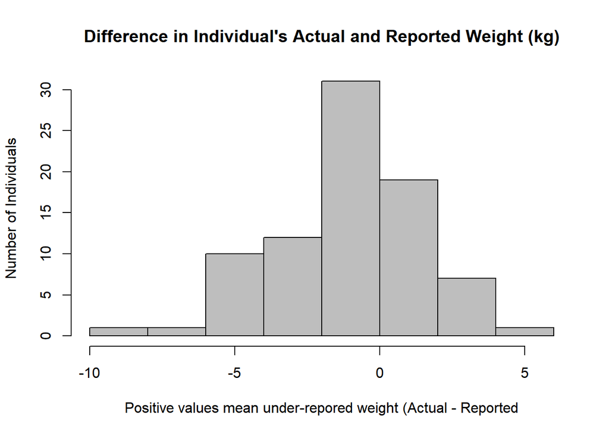

```r
hist(
  DavisM$weight - DavisM$repwt,
  col = "gray",
  main = "Difference in Individual's Actual and Reported Weight (kg)",
  ylab = "Number of Individuals",
  xlab = "Positive values mean under-repored weight (Actual - Reported"
)
```